# Aprendizaje supervisado - Fundamentos del proyecto: ReCell

## Descripción del problema

### Contexto empresarial

La compra y venta de teléfonos y tabletas usados solía ser algo que sucedía en un puñado de sitios de mercado en línea. Pero el mercado de dispositivos usados y reacondicionados ha crecido considerablemente durante la última década, y un nuevo pronóstico de IDC (International Data Corporation) predice que el mercado de teléfonos usados tendrá un valor de \$52.700 millones para 2023 con una tasa de crecimiento anual compuesto (CAGR) de 13,6 % de 2018 a 2023. Este crecimiento se puede atribuir a un aumento en la demanda de teléfonos y tabletas usados que ofrecen ahorros considerables en comparación con los nuevos modelos.

Los dispositivos reacondicionados y usados continúan brindando alternativas rentables tanto para los consumidores como para las empresas que buscan ahorrar dinero al comprar uno. Hay muchos otros beneficios asociados con el mercado de dispositivos usados. Los dispositivos usados y reacondicionados se pueden vender con garantía y también se pueden asegurar con el comprobante de compra. Proveedores/plataformas de terceros, como Verizon, Amazon, etc., ofrecen ofertas atractivas a los clientes para dispositivos reacondicionados. Maximizar la longevidad de los dispositivos a través del comercio de segunda mano también reduce su impacto ambiental y ayuda a reciclar y reducir los desechos. El impacto del brote de COVID-19 puede impulsar aún más este segmento, ya que los consumidores reducen los gastos discrecionales y compran teléfonos y tabletas solo para necesidades inmediatas.

### Objetivo

El creciente potencial de este mercado comparativamente bajo el radar alimenta la necesidad de una solución basada en ML para desarrollar una estrategia de precios dinámica para dispositivos usados y reacondicionados. ReCell, una startup que busca aprovechar el potencial de este mercado, lo ha contratado como científico de datos. Quieren que analice los datos proporcionados y construya un modelo de regresión lineal para predecir el precio de un teléfono/tableta usado e identificar los factores que lo influyen significativamente.

### Descripción de datos

Los datos contienen los diferentes atributos de teléfonos y tabletas usados/reacondicionados. Los datos se recopilaron en el año 2021. El diccionario de datos detallado se proporciona a continuación.

--brand_name: Nombre de la marca de fabricación

-os: sistema operativo en el que se ejecuta el dispositivo

-screen_size: Tamaño de la pantalla en cm

-4g: si 4G está disponible o no

-5g: si 5G está disponible o no

-main_camera_mp: Resolución de la cámara trasera en megapíxeles

-selfie_camera_mp: Resolución de la cámara frontal en megapíxeles

-int_memory: Cantidad de memoria interna (ROM) en GB

-ram: cantidad de RAM en GB

-battery: capacidad energética de la batería del dispositivo en mAh

-weight: Peso del dispositivo en gramos

-release_year: año en que se lanzó el modelo del dispositivo

-days_used: número de días que se ha utilizado el dispositivo usado/reconstruido

-normalized_new_price: Precio normalizado de un dispositivo nuevo del mismo modelo en euros

-normalized_used_price: Precio normalizado del dispositivo usado/reacondicionado en euros

## Importar librerias necesarias

```python
import numpy as np
import pandas as pd
import matplotlib.pyplot as plt
import seaborn as sns

sns.set()

from sklearn.model_selection import train_test_split
from sklearn.linear_model import LinearRegression
from sklearn.metrics import mean_absolute_error, mean_squared_error, r2_score
import statsmodels.api as sm
from statsmodels.stats.outliers_influence import variance_inflation_factor
```

```python
pd.set_option('display.float_format', lambda x: '%.3f' % x)
```

## Cargando el conjunto de datos

```python
df = pd.read_csv('used_device_data.csv')
```

## Resumen de datos

Observaciones y pruebas de cordura

- Resumen de datos
- Ver la primera y la última fila del conjunto de datos
- Comprobación de la forma del conjunto de datos.
- Obtener el resumen estadístico de las variables.
- Comprobar valores perdidos
- Buscar duplicados

```python
df.head() ##mostrar los 5 primeros elementos del dataframe
```

|  | brand_name | os | screen_size | 4g | 5g | main_camera_mp | selfie_camera_mp | int_memory | ram | battery | weight | release_year | days_used | normalized_used_price | normalized_new_price |
| --- | --- | --- | --- | --- | --- | --- | --- | --- | --- | --- | --- | --- | --- | --- | --- |
| 0 | Honor | Android | 14.500 | yes | no | 13.000 | 5.000 | 64.000 | 3.000 | 3020.000 | 146.000 | 2020 | 127 | 4.308 | 4.715 |
| 1 | Honor | Android | 17.300 | yes | yes | 13.000 | 16.000 | 128.000 | 8.000 | 4300.000 | 213.000 | 2020 | 325 | 5.162 | 5.519 |
| 2 | Honor | Android | 16.690 | yes | yes | 13.000 | 8.000 | 128.000 | 8.000 | 4200.000 | 213.000 | 2020 | 162 | 5.111 | 5.885 |
| 3 | Honor | Android | 25.500 | yes | yes | 13.000 | 8.000 | 64.000 | 6.000 | 7250.000 | 480.000 | 2020 | 345 | 5.135 | 5.631 |
| 4 | Honor | Android | 15.320 | yes | no | 13.000 | 8.000 | 64.000 | 3.000 | 5000.000 | 185.000 | 2020 | 293 | 4.390 | 4.948 |

```python
df.tail() ##mostrar los ultimos 5 elementos del dataframe
```

|  | brand_name | os | screen_size | 4g | 5g | main_camera_mp | selfie_camera_mp | int_memory | ram | battery | weight | release_year | days_used | normalized_used_price | normalized_new_price |
| --- | --- | --- | --- | --- | --- | --- | --- | --- | --- | --- | --- | --- | --- | --- | --- |
| 3449 | Asus | Android | 15.340 | yes | no | NaN | 8.000 | 64.000 | 6.000 | 5000.000 | 190.000 | 2019 | 232 | 4.492 | 6.484 |
| 3450 | Asus | Android | 15.240 | yes | no | 13.000 | 8.000 | 128.000 | 8.000 | 4000.000 | 200.000 | 2018 | 541 | 5.038 | 6.252 |
| 3451 | Alcatel | Android | 15.800 | yes | no | 13.000 | 5.000 | 32.000 | 3.000 | 4000.000 | 165.000 | 2020 | 201 | 4.357 | 4.529 |
| 3452 | Alcatel | Android | 15.800 | yes | no | 13.000 | 5.000 | 32.000 | 2.000 | 4000.000 | 160.000 | 2020 | 149 | 4.350 | 4.624 |
| 3453 | Alcatel | Android | 12.830 | yes | no | 13.000 | 5.000 | 16.000 | 2.000 | 4000.000 | 168.000 | 2020 | 176 | 4.132 | 4.280 |

```python
print("There are", df.shape[0], 'rows and', df.shape[1], "columns.") ##muesta la estructuras del dataframe
```

```
There are 3454 rows and 15 columns.
```

```python
df.info() ## se muestra un resumen conciso del dataframe
```

```
<class 'pandas.core.frame.DataFrame'>
RangeIndex: 3454 entries, 0 to 3453
Data columns (total 15 columns):
 #   Column                 Non-Null Count  Dtype
---  ------                 --------------  -----
 0   brand_name             3454 non-null   object
 1   os                     3454 non-null   object
 2   screen_size            3454 non-null   float64
 3   4g                     3454 non-null   object
 4   5g                     3454 non-null   object
 5   main_camera_mp         3275 non-null   float64
 6   selfie_camera_mp       3452 non-null   float64
 7   int_memory             3450 non-null   float64
 8   ram                    3450 non-null   float64
 9   battery                3448 non-null   float64
 10  weight                 3447 non-null   float64
 11  release_year           3454 non-null   int64
 12  days_used              3454 non-null   int64
 13  normalized_used_price  3454 non-null   float64
 14  normalized_new_price   3454 non-null   float64
dtypes: float64(9), int64(2), object(4)
memory usage: 404.9+ KB
```

Podemos ver que hay 9 variables con 3454 observaciones y las otras 6 restantes podemos ver que cuentan con menos observaciones. Tambien podemos observar que 4 variables son de tipo objeto y las demás son variables numericas.

```python
df.describe(include ='all').T
```

|  | count | unique | top | freq | mean | std | min | 25% | 50% | 75% | max |
| --- | --- | --- | --- | --- | --- | --- | --- | --- | --- | --- | --- |
| brand_name | 3454 | 34 | Others | 502 | NaN | NaN | NaN | NaN | NaN | NaN | NaN |
| os | 3454 | 4 | Android | 3214 | NaN | NaN | NaN | NaN | NaN | NaN | NaN |
| screen_size | 3454.000 | NaN | NaN | NaN | 13.713 | 3.805 | 5.080 | 12.700 | 12.830 | 15.340 | 30.710 |
| 4g | 3454 | 2 | yes | 2335 | NaN | NaN | NaN | NaN | NaN | NaN | NaN |
| 5g | 3454 | 2 | no | 3302 | NaN | NaN | NaN | NaN | NaN | NaN | NaN |
| main_camera_mp | 3275.000 | NaN | NaN | NaN | 9.460 | 4.815 | 0.080 | 5.000 | 8.000 | 13.000 | 48.000 |
| selfie_camera_mp | 3452.000 | NaN | NaN | NaN | 6.554 | 6.970 | 0.000 | 2.000 | 5.000 | 8.000 | 32.000 |
| int_memory | 3450.000 | NaN | NaN | NaN | 54.573 | 84.972 | 0.010 | 16.000 | 32.000 | 64.000 | 1024.000 |
| ram | 3450.000 | NaN | NaN | NaN | 4.036 | 1.365 | 0.020 | 4.000 | 4.000 | 4.000 | 12.000 |
| battery | 3448.000 | NaN | NaN | NaN | 3133.403 | 1299.683 | 500.000 | 2100.000 | 3000.000 | 4000.000 | 9720.000 |
| weight | 3447.000 | NaN | NaN | NaN | 182.752 | 88.413 | 69.000 | 142.000 | 160.000 | 185.000 | 855.000 |
| release_year | 3454.000 | NaN | NaN | NaN | 2015.965 | 2.298 | 2013.000 | 2014.000 | 2015.500 | 2018.000 | 2020.000 |
| days_used | 3454.000 | NaN | NaN | NaN | 674.870 | 248.580 | 91.000 | 533.500 | 690.500 | 868.750 | 1094.000 |
| normalized_used_price | 3454.000 | NaN | NaN | NaN | 4.365 | 0.589 | 1.537 | 4.034 | 4.405 | 4.756 | 6.619 |
| normalized_new_price | 3454.000 | NaN | NaN | NaN | 5.233 | 0.684 | 2.901 | 4.790 | 5.246 | 5.674 | 7.848 |

```python
df.isnull().sum()
```

```
brand_name                 0
os                         0
screen_size                0
4g                         0
5g                         0
main_camera_mp           179
selfie_camera_mp           2
int_memory                 4
ram                        4
battery                    6
weight                     7
release_year               0
days_used                  0
normalized_used_price      0
normalized_new_price       0
dtype: int64
```

Podemos observar que el dataframe si cuenta con valores perdidos.

- 179 valores perdidos en la variable de "main_camera_mp".
- 2 valores en "selfie_camera_mp".
- 4 valores en "int_memory".
- 4 valores en "ram".
- 6 valores en "battery".
- 7 valores en "weight".

```python
df.duplicated().sum()
```

```
0
```

Podemos observar que el df no cuenta con valores duplicados.

## Análisis exploratorio de datos (EDA)

- EDA es una parte importante de cualquier proyecto que involucre datos.
- Es importante investigar y comprender mejor los datos antes de construir un modelo con ellos.
- A continuación se mencionan algunas preguntas que lo ayudarán a abordar el análisis de la manera correcta y generar conocimientos a partir de los datos.
- Se debe realizar un análisis exhaustivo de los datos, además de las preguntas que se mencionan a continuación.

**Preguntas**:

1. ¿Cómo es la distribución de precios normalizados de dispositivos usados?
2. ¿Qué porcentaje del mercado de dispositivos usados está dominado por dispositivos Android?
3. La cantidad de RAM es importante para el buen funcionamiento de un dispositivo. ¿Cómo varía la cantidad de RAM según la marca?
4. Una batería grande a menudo aumenta el peso del dispositivo, lo que hace que se sienta incómodo en las manos. ¿Cómo varía el peso de los teléfonos y tabletas que ofrecen baterías grandes (más de 4500 mAh)?
5. Las pantallas más grandes son deseables para fines de entretenimiento, ya que ofrecen una mejor experiencia de visualización. ¿Cuántos teléfonos y tabletas están disponibles en diferentes marcas con un tamaño de pantalla de más de 6 pulgadas?
6. Hoy en día, muchos dispositivos ofrecen excelentes cámaras para selfies, lo que nos permite capturar nuestros momentos favoritos con nuestros seres queridos. ¿Cuál es la distribución de dispositivos que ofrecen cámaras para selfies de más de 8 MP entre marcas?
7. ¿Qué atributos están altamente correlacionados con el precio normalizado de un dispositivo usado?

### Analisis univariado

A continuacion se presentara el analisis visual de las variables numericas del df.

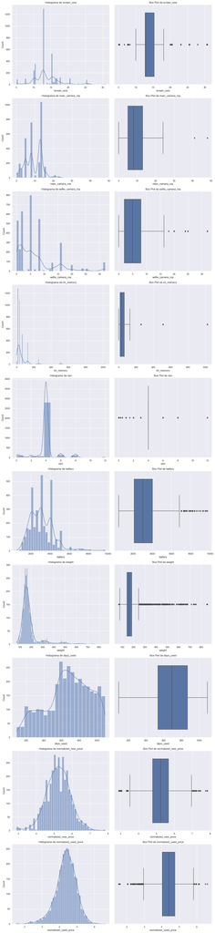

```python
import matplotlib.pyplot as plt
import seaborn as sns

# Lista de atributos que deseas visualizar
attributes_to_visualize = [
    'screen_size', 'main_camera_mp', 'selfie_camera_mp', 'int_memory',
    'ram', 'battery', 'weight', 'days_used',
    'normalized_new_price', 'normalized_used_price'
]

# Configuración de la figura y los ejes
num_rows = len(attributes_to_visualize)
fig, axes = plt.subplots(nrows=num_rows, ncols=2, figsize=(14, num_rows * 6))
plt.subplots_adjust(hspace=0.5)

# Creación de histogramas y box plots para cada atributo
for i, attribute in enumerate(attributes_to_visualize):
    sns.histplot(df[attribute], ax=axes[i, 0], kde=True)
    axes[i, 0].set_title(f'Histograma de {attribute}')

    sns.boxplot(x=df[attribute], ax=axes[i, 1])
    axes[i, 1].set_title(f'Box Plot de {attribute}')

# Mostrar las visualizaciones
plt.tight_layout()
plt.show()
```

### Observaciones

#### ¿Cómo es la distribución de precios normalizados de dispositivos usados?

- normalized used price: Podemos ver que los datos siguen una distribucion normal con un ligero sesgo a la izquierda, de igual manera podemos ver que existen valores atípicos los cuales pueden tener relacion a que el precio se ve a afectado por otras variables.

Analisis visual de las variables categoricas y temporales

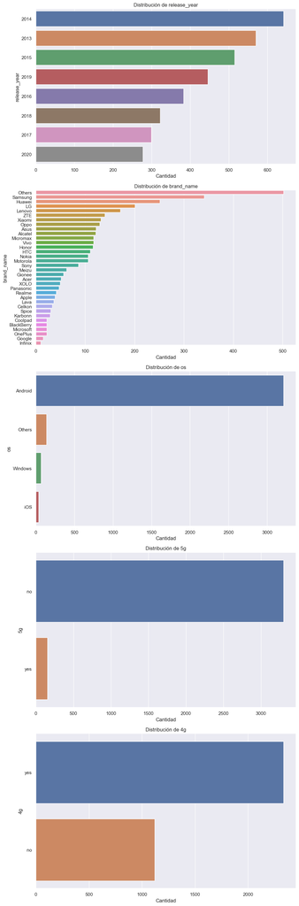

```python
# Lista de variables categóricas para visualizar
categorical_variables = ['release_year', 'brand_name', 'os', '5g', '4g']

# Configuración de la figura y los ejes
num_rows = len(categorical_variables)
fig, axes = plt.subplots(nrows=num_rows, figsize=(10, num_rows * 6))
plt.subplots_adjust(hspace=0.5)

# Creación de gráficos de barras etiquetados
for i, variable in enumerate(categorical_variables):
    sns.countplot(data=df, y=variable, ax=axes[i], order=df[variable].value_counts().index)
    axes[i].set_title(f'Distribución de {variable}')
    axes[i].set_ylabel(variable)
    axes[i].set_xlabel('Cantidad')

# Mostrar las visualizaciones
plt.tight_layout()
plt.show()
```

### Observaciones

- release year: la mayoria de los dispositivos salieron al mercado en 2014
- brand name: podemos observar que la mayoria de los dispositivos son de marcas no listadas individualmente, seguidas por samsung y huawei
- os: la mayoria de los dispositivos usa android como sistema operativo predeterminado
- 5g: la mayoria de los dispositivos no cuenta con 5g
- 4g: la mayoria de los dispositivos cuenta con 4g

#### ¿Qué porcentaje del mercado de dispositivos usados está dominado por dispositivos Android?

```python
# Filtrar dispositivos Android
android_devices_df = df[df['os'] == 'Android']

# Contar la cantidad de dispositivos Android
android_devices_count = android_devices_df.shape[0]

# Contar la cantidad total de dispositivos
total_devices = df.shape[0]

# Calcular el porcentaje
percentage_android = (android_devices_count / total_devices) * 100

# Obtener las marcas de teléfonos Android únicas
android_brands = android_devices_df['brand_name'].unique()

# Imprimir el resultado
print(f"El porcentaje del mercado de dispositivos usados dominado por dispositivos Android es: {percentage_android:.2f}%")
print("Las marcas de teléfonos Android en el mercado son:")
for brand in android_brands:
    print(brand)
```

```
El porcentaje del mercado de dispositivos usados dominado por dispositivos Android es: 93.05%
Las marcas de teléfonos Android en el mercado son:
Honor
Others
HTC
Huawei
Infinix
Lava
Lenovo
LG
Meizu
Micromax
Motorola
Nokia
OnePlus
Oppo
Realme
Samsung
Vivo
Xiaomi
ZTE
Asus
Coolpad
Acer
Alcatel
BlackBerry
Celkon
Gionee
Google
Karbonn
Panasonic
Sony
Spice
XOLO
```

### Analisis Bivariado

A continuacion se realizará el analisis bivariado para poder observar las relaciones que hay entre las variables.

#### La cantidad de RAM es importante para el buen funcionamiento de un dispositivo. ¿Cómo varía la cantidad de RAM según la marca?

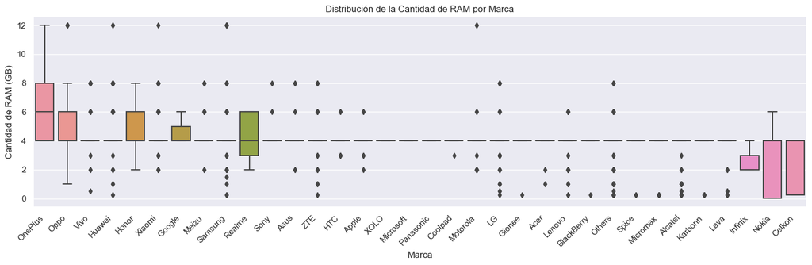

```
Estadísticas de RAM según la marca:
            mean  median   std   min    max
brand_name
OnePlus    6.364   6.000 2.592 4.000 12.000
Oppo       4.961   4.000 2.123 1.000 12.000
Vivo       4.756   4.000 1.638 0.500  8.000
Huawei     4.655   4.000 1.595 0.250 12.000
Honor      4.603   4.000 1.625 2.000  8.000
Xiaomi     4.583   4.000 1.508 2.000 12.000
Google     4.533   4.000 0.915 4.000  6.000
Meizu      4.452   4.000 1.224 2.000  8.000
Samsung    4.199   4.000 1.377 0.250 12.000
Realme     4.195   4.000 1.327 2.000  6.000
Sony       4.070   4.000 0.480 4.000  8.000
Asus       4.049   4.000 0.601 2.000  8.000
ZTE        4.023   4.000 0.910 0.250  8.000
HTC        4.000   4.000 0.332 3.000  6.000
Apple      4.000   4.000 0.607 2.000  6.000
XOLO       4.000   4.000 0.000 4.000  4.000
Microsoft  4.000   4.000 0.000 4.000  4.000
Panasonic  4.000   4.000 0.000 4.000  4.000
Coolpad    3.955   4.000 0.213 3.000  4.000
Motorola   3.943   4.000 1.330 2.000 12.000
LG         3.937   4.000 1.076 0.250  8.000
Gionee     3.933   4.000 0.501 0.250  4.000
Acer       3.902   4.000 0.500 1.000  4.000
Lenovo     3.886   4.000 0.774 0.250  6.000
BlackBerry 3.830   4.000 0.800 0.250  4.000
Others     3.778   4.000 1.016 0.250  8.000
Spice      3.750   4.000 0.951 0.250  4.000
Micromax   3.679   4.000 1.053 0.250  4.000
Alcatel    3.407   4.000 1.264 0.250  4.000
Karbonn    3.353   4.000 1.442 0.250  4.000
Lava       3.278   4.000 1.414 0.250  4.000
Infinix    2.600   2.000 0.843 2.000  4.000
Nokia      2.420   4.000 1.889 0.020  6.000
Celkon     1.614   0.250 1.832 0.250  4.000
```

```python
# Agrupar por marca y calcular estadísticas de RAM
ram_stats_by_brand = df.groupby('brand_name')['ram'].agg(['mean', 'median', 'std', 'min', 'max'])

# Ordenar los resultados por la media de RAM en orden descendente
ram_stats_by_brand = ram_stats_by_brand.sort_values(by='mean', ascending=False)

# Configuración de la figura y los ejes con ejes invertidos
plt.figure(figsize=(15, 5))
sns.boxplot(data=df, y='ram', x='brand_name', order=ram_stats_by_brand.index)
plt.ylabel('Cantidad de RAM (GB)')
plt.xlabel('Marca')
plt.title('Distribución de la Cantidad de RAM por Marca')
plt.xticks(rotation=45, ha='right')  # Rotar etiquetas en el eje x para mayor claridad
plt.tight_layout()
plt.show()

# Imprimir las estadísticas de RAM por marca
print("Estadísticas de RAM según la marca:")
print(ram_stats_by_brand)
```

### Observaciones

#### Una batería grande a menudo aumenta el peso del dispositivo, lo que hace que se sienta incómodo en las manos. ¿Cómo varía el peso de los teléfonos y tabletas que ofrecen baterías grandes (más de 4500 mAh)?

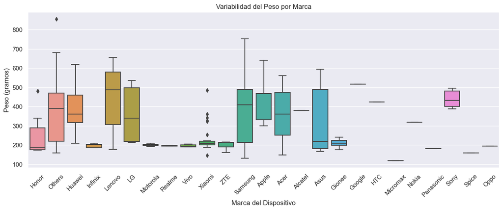

```
Estadísticas de bateria según la marca:
               mean   median      std      min      max
brand_name
Infinix    4800.000 5000.000  788.811 4000.000 6000.000
Apple      4628.910 3937.000 2638.295 1510.000 9720.000
Realme     4337.317 4200.000  473.690 3410.000 5000.000
Xiaomi     3979.848 4000.000  986.505 2000.000 8620.000
Huawei     3745.159 4000.000 1315.356 1350.000 7500.000
Vivo       3718.846 3900.000  825.407 1900.000 5000.000
OnePlus    3716.591 3800.000  497.013 2525.000 4300.000
Honor      3690.517 3750.000  881.778 1730.000 7250.000
Google     3628.333 3430.000 1600.524 2700.000 9240.000
Lenovo     3618.480 3450.000 1632.362 1300.000 9600.000
Asus       3499.836 3300.000 1171.116 1170.000 7800.000
Oppo       3380.581 3600.000  850.842 1700.000 5000.000
Meizu      3368.220 3150.000  523.260 2400.000 4500.000
Samsung    3362.683 3000.000 1690.288  800.000 9500.000
Motorola   3312.594 3000.000  906.572 1785.000 5000.000
Gionee     3117.946 3000.000 1328.959 1500.000 7000.000
LG         3033.980 3000.000 1165.156  950.000 8200.000
Sony       3003.372 2870.000  960.066 1700.000 6000.000
Acer       2999.608 2700.000 1340.679 1300.000 7300.000
Coolpad    2945.000 2650.000  761.720 1800.000 4070.000
ZTE        2894.821 2975.000  931.840  500.000 5100.000
BlackBerry 2822.500 2840.000  746.231 1450.000 4000.000
Others     2821.952 2500.000 1224.097  620.000 9000.000
Panasonic  2682.979 2500.000  775.914 1300.000 5000.000
HTC        2614.455 2600.000  708.434 1230.000 6700.000
Alcatel    2452.975 2500.000  864.473  750.000 4600.000
Microsoft  2382.381 2500.000  646.650 1500.000 3340.000
Nokia      2259.615 2000.000 1079.476 1000.000 5300.000
Lava       2248.611 2000.000  639.996 1400.000 4000.000
Micromax   2224.786 2000.000  665.922 1200.000 4800.000
XOLO       2220.000 2100.000  679.589 1400.000 4100.000
Spice      2191.000 2100.000 1074.685 1300.000 7600.000
Karbonn    1724.138 1625.000  219.423 1350.000 2300.000
Celkon     1475.758 1400.000  315.268 1200.000 3000.000
```

```python
df_high_battery = df[df.battery > 4500] #filtrar los dispositivos que cuenten con una bateria de mas de 4500 mAh
df_high_battery_stats = df.groupby('brand_name')['battery'].agg(['mean', 'median', 'std', 'min', 'max'])
df_high_battery_stats = df_high_battery_stats.sort_values(by='mean', ascending=False)
plt.figure(figsize=(15, 5))
sns.boxplot(x='brand_name', y='weight', data=df_high_battery)
plt.xticks(rotation=45)  # Rotar las etiquetas del eje x para mejorar la legibilidad
plt.title('Variabilidad del Peso por Marca')
plt.xlabel('Marca del Dispositivo')
plt.ylabel('Peso (gramos)')
plt.show()
print("Estadísticas de bateria según la marca:")
print(df_high_battery_stats)
```

### Observaciones

- Infinix encabeza la lista con un promedio de 4800 mAh, seguido por Apple y Realme. Las marcas como Karbonn y Celkon tienen los promedios más bajos, lo que indica que sus dispositivos tienden a tener baterías con menos capacidad.
- Las marcas como Apple, Xiaomi, Huawei y Samsung tienen un amplio rango de capacidades de batería, lo que indica una diversidad en su oferta de productos desde dispositivos de gama baja hasta gama alta.
- Apple tiene un promedio notablemente alto, pero su amplia desviación estándar sugiere una gran variabilidad, desde dispositivos con baterías más pequeñas hasta dispositivos con algunas de las capacidades más altas en el conjunto de datos. Infinix, a pesar de no ser tan conocido como algunas de las otras marcas, destaca por su alta capacidad promedio de batería.

#### Las pantallas más grandes son deseables para fines de entretenimiento, ya que ofrecen una mejor experiencia de visualización. ¿Cuántos teléfonos y tabletas están disponibles en diferentes marcas con un tamaño de pantalla de más de 6 pulgadas?

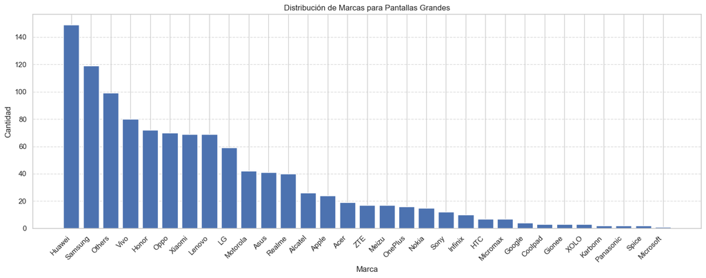

```
brand_name
Huawei       149
Samsung      119
Others        99
Vivo          80
Honor         72
Oppo          70
Xiaomi        69
Lenovo        69
LG            59
Motorola      42
Asus          41
Realme        40
Alcatel       26
Apple         24
Acer          19
ZTE           17
Meizu         17
OnePlus       16
Nokia         15
Sony          12
Infinix       10
HTC            7
Micromax       7
Google         4
Coolpad        3
Gionee         3
XOLO           3
Karbonn        2
Panasonic      2
Spice          2
Microsoft      1
Name: count, dtype: int64
```

```python
# Filtra los datos para pantallas grandes
df_large_screen = df[df.screen_size > 6 * 2.54]

# Configura el estilo de la figura
plt.figure(figsize=(15, 6))
sns.set_style("whitegrid")

# Crea el gráfico de barras etiquetado con estilo personalizado
plt.bar(df_large_screen["brand_name"].value_counts().index,
        df_large_screen["brand_name"].value_counts().values)

# Añade título y etiquetas a los ejes
plt.title("Distribución de Marcas para Pantallas Grandes")
plt.xlabel("Marca")
plt.ylabel("Cantidad")

# Rota las etiquetas del eje x para mejor legibilidad
plt.xticks(rotation=45, ha="right")

# Añade una cuadrícula horizontal para mayor claridad
plt.grid(axis="y", linestyle="--", alpha=0.7)

# Ajusta el espaciado entre las barras
plt.tight_layout()

# Muestra el gráfico
plt.show()
df_large_screen["brand_name"].value_counts()
```

### Observaciones

Huawei lidera la lista de marcas que ofrecen dispositivos con pantallas mayores a 6 pulgadas, seguido por Samsung y la categoría "Others" que son marcas no listadas.

#### Hoy en día, muchos dispositivos ofrecen excelentes cámaras para selfies, lo que nos permite capturar nuestros momentos favoritos con nuestros seres queridos. ¿Cuál es la distribución de dispositivos que ofrecen cámaras para selfies de más de 8 MP entre marcas?

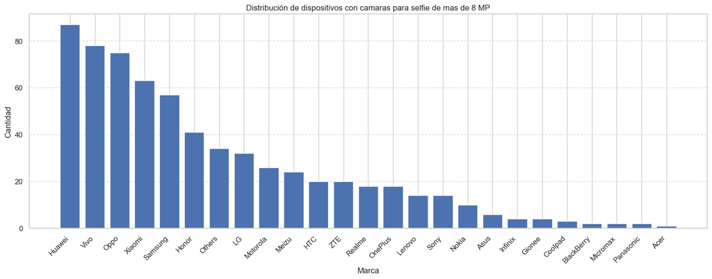

```
brand_name
Huawei        87
Vivo          78
Oppo          75
Xiaomi        63
Samsung       57
Honor         41
Others        34
LG            32
Motorola      26
Meizu         24
HTC           20
ZTE           20
Realme        18
OnePlus       18
Lenovo        14
Sony          14
Nokia         10
Asus           6
Infinix        4
Gionee         4
Coolpad        3
BlackBerry     2
Micromax       2
Panasonic      2
Acer           1
Name: count, dtype: int64
```

```python
df_selfie=df[df.selfie_camera_mp>8]
# Configura el estilo de la figura
plt.figure(figsize=(15, 6))
sns.set_style("whitegrid")

# Crea el gráfico de barras etiquetado con estilo personalizado
plt.bar(df_selfie["brand_name"].value_counts().index,
        df_selfie["brand_name"].value_counts().values)

# Añade título y etiquetas a los ejes
plt.title("Distribución de dispositivos con camaras para selfie de mas de 8 MP")
plt.xlabel("Marca")
plt.ylabel("Cantidad")

# Rota las etiquetas del eje x para mejor legibilidad
plt.xticks(rotation=45, ha="right")

# Añade una cuadrícula horizontal para mayor claridad
plt.grid(axis="y", linestyle="--", alpha=0.7)

# Ajusta el espaciado entre las barras
plt.tight_layout()

# Muestra el gráfico
plt.show()
df_selfie["brand_name"].value_counts()
```

### Observaciones

Huawei encabeza la lista, seguido muy de cerca por Vivo y Oppo. Al final de la lista, encontramos marcas como Acer, Micromax, y BlackBerry con una presencia mínima en este nicho del mercado.

#### ¿Qué atributos están altamente correlacionados con el precio normalizado de un dispositivo usado?

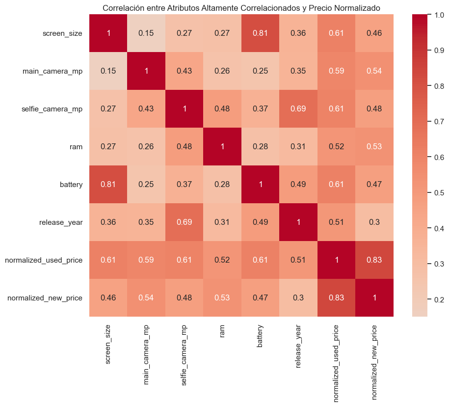

```python
# Filtra las columnas numéricas para el cálculo de correlación
numeric_columns = df.select_dtypes(include=[np.number])

# Calcula la matriz de correlación
correlation_matrix = numeric_columns.corr()

# Filtra las correlaciones con respecto al precio normalizado
price_corr = correlation_matrix["normalized_used_price"]

# Filtra las correlaciones significativas (puedes ajustar este umbral)
significant_corr = price_corr[abs(price_corr) > 0.5]

# Selecciona los atributos altamente correlacionados
highly_correlated_attrs = significant_corr.index.tolist()

# Crea un mapa de calor de las correlaciones
plt.figure(figsize=(10, 8))
sns.heatmap(numeric_columns[highly_correlated_attrs].corr(), annot=True, cmap="coolwarm", center=0)
plt.title("Correlación entre Atributos Altamente Correlacionados y Precio Normalizado")
plt.show()
```

## Procesamiento de datos

- Tratamiento de valores perdidos
- Ingeniería de características (si es necesario)
- Detección y tratamiento de valores atípicos (si es necesario)
- Preparación de datos para el modelado.
- Cualquier otro paso de preprocesamiento (si es necesario)

primero para el tratamiento de valores perdidos crearemos una copia del df para no modificar el df original, para poder hacer la imputacion de valores en la mediana de las columnas pertinentes.

```python
dfn=df.copy()
```

```python
dfn.isnull().sum()
```

```
brand_name                 0
os                         0
screen_size                0
4g                         0
5g                         0
main_camera_mp           179
selfie_camera_mp           2
int_memory                 4
ram                        4
battery                    6
weight                     7
release_year               0
days_used                  0
normalized_used_price      0
normalized_new_price       0
dtype: int64
```

imputacion de valores faltantes mediante la mediana

```python
# Columnas en las que quieres imputar valores faltantes
columns_to_impute = ["main_camera_mp", "selfie_camera_mp", "int_memory", "ram", "battery", "weight"]

# Agrupa por "release_date" y "brand_name" y calcula las medianas
medians = dfn.groupby(["release_year", "brand_name"])[columns_to_impute].median()

# Función para imputar valores faltantes por las medianas
def impute_missing_values(row):
    key = (row["release_year"], row["brand_name"])
    return medians.loc[key][columns_to_impute]

# Aplica la función de imputación a las filas con valores faltantes
dfn[columns_to_impute] = dfn.apply(lambda row: row[columns_to_impute] if pd.notnull(row[columns_to_impute]).all() else impute_missing_values(row), axis=1)
dfn.isnull().sum()
```

```
brand_name                 0
os                         0
screen_size                0
4g                         0
5g                         0
main_camera_mp           179
selfie_camera_mp           2
int_memory                 0
ram                        0
battery                    6
weight                     7
release_year               0
days_used                  0
normalized_used_price      0
normalized_new_price       0
dtype: int64
```

```python
# Columnas en las que quieres imputar valores faltantes
columns_to_impute = ["main_camera_mp", "selfie_camera_mp", "battery", "weight"]

# Agrupa por "brand_name" y calcula las medianas
medians = dfn.groupby("brand_name")[columns_to_impute].median()

# Función para imputar valores faltantes por las medianas
def impute_missing_values(row):
    brand = row["brand_name"]
    return medians.loc[brand][columns_to_impute]

# Aplica la función de imputación a las filas con valores faltantes
dfn[columns_to_impute] = dfn.apply(lambda row: row[columns_to_impute] if pd.notnull(row[columns_to_impute]).all() else impute_missing_values(row), axis=1)
dfn.isnull().sum()
```

```
brand_name                0
os                        0
screen_size               0
4g                        0
5g                        0
main_camera_mp           10
selfie_camera_mp          0
int_memory                0
ram                       0
battery                   0
weight                    0
release_year              0
days_used                 0
normalized_used_price     0
normalized_new_price      0
dtype: int64
```

```python
# Columna en la que quieres imputar valores faltantes
column_to_impute = "main_camera_mp"

# Calcula la mediana de la columna
median_value = dfn[column_to_impute].median()

# Imputa los valores faltantes con la mediana
dfn[column_to_impute].fillna(median_value, inplace=True)
dfn.isnull().sum()
```

```
brand_name               0
os                       0
screen_size              0
4g                       0
5g                       0
main_camera_mp           0
selfie_camera_mp         0
int_memory               0
ram                      0
battery                  0
weight                   0
release_year             0
days_used                0
normalized_used_price    0
normalized_new_price     0
dtype: int64
```

ahora que ya no tenemos valores faltantes, podemos seguir con el tratamiento de datos.

crearemos una variable a partir de la variable "release_year" llamada, "years_since_release", la cual nos permitira capturar la informacion releveante de una manera más útil para el modelo, ya que de esta manera crearemos una caracteristica que tiene una relacion más directa con el tiempo transcurrido desde la fecha de lanzamiento.

```python
# Calcula la nueva variable "years_since_release"
dfn["years_since_release"] = 2021 - dfn["release_year"]

# eliminar la columna "release_year"
dfn.drop(columns=["release_year"], inplace=True)
dfn["years_since_release"].describe()
```

```
count   3454.000
mean       5.035
std        2.298
min        1.000
25%        3.000
50%        5.500
75%        7.000
max        8.000
Name: years_since_release, dtype: float64
```

## EDA

- Es una buena idea explorar los datos una vez más después de manipularlos.

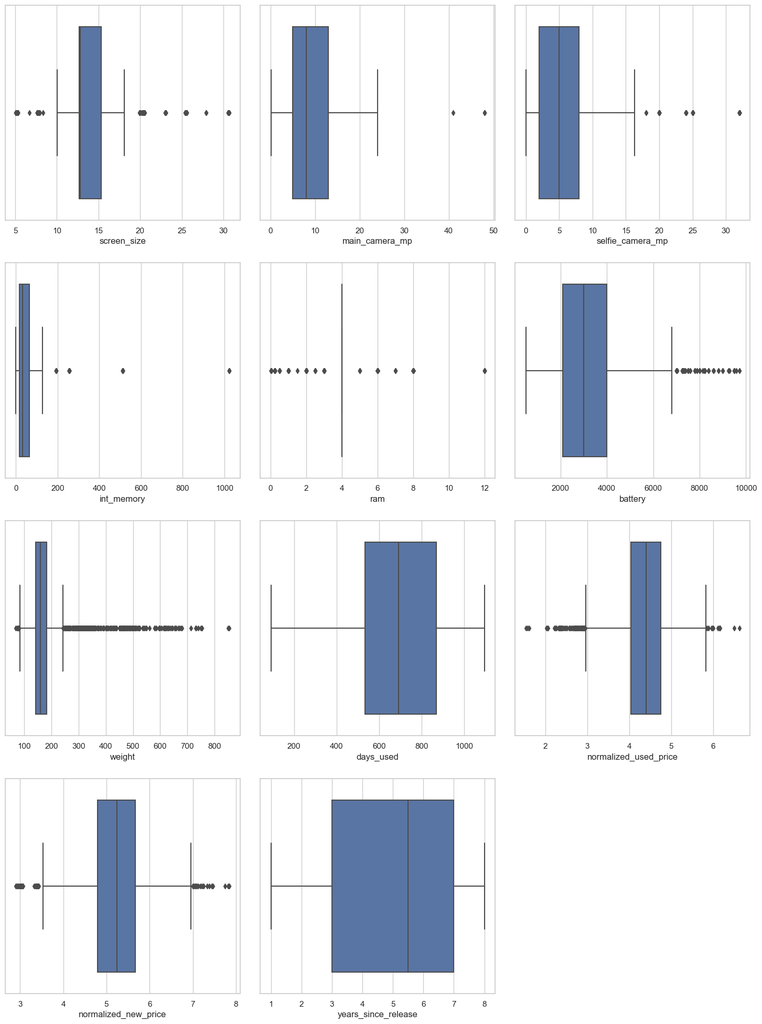

```python
# Columnas numéricas en el DataFrame
num_cols = dfn.select_dtypes(include=np.number).columns.tolist()

# Ajusta el número de filas y columnas según la cantidad de variables
num_rows = int(np.ceil(len(num_cols) / 3))
num_cols_subplot = min(len(num_cols), 3)

plt.figure(figsize=(15, num_rows * 5))

for i, variable in enumerate(num_cols):
    plt.subplot(num_rows, num_cols_subplot, i + 1)
    sns.boxplot(data=dfn, x=variable)
    plt.tight_layout(pad=2)

plt.show()
```

Al examinar los boxplots generados para las variables relacionadas con las características de los dispositivos móviles usados, podemos obtener valiosa información sobre la distribución y variabilidad de estos atributos. Las boxplots nos permiten observar la mediana, los cuartiles y la presencia de valores atípicos en las variables.

## Construyendo el modelo - Regresión Lineal

primero se preparan los datos para el modelado.

Se busca crear un modelo que prediga el precio normalizado de los dispositivos usados, por lo tanto tendremos datos de entrenamiento y de prueba, los cuales nos permitiran verificar la productividad del modelo.

```python
dfn.head()
```

|  | brand_name | os | screen_size | 4g | 5g | main_camera_mp | selfie_camera_mp | int_memory | ram | battery | weight | days_used | normalized_used_price | normalized_new_price | years_since_release |
| --- | --- | --- | --- | --- | --- | --- | --- | --- | --- | --- | --- | --- | --- | --- | --- |
| 0 | Honor | Android | 14.500 | yes | no | 13.000 | 5.000 | 64.000 | 3.000 | 3020.000 | 146.000 | 127 | 4.308 | 4.715 | 1 |
| 1 | Honor | Android | 17.300 | yes | yes | 13.000 | 16.000 | 128.000 | 8.000 | 4300.000 | 213.000 | 325 | 5.162 | 5.519 | 1 |
| 2 | Honor | Android | 16.690 | yes | yes | 13.000 | 8.000 | 128.000 | 8.000 | 4200.000 | 213.000 | 162 | 5.111 | 5.885 | 1 |
| 3 | Honor | Android | 25.500 | yes | yes | 13.000 | 8.000 | 64.000 | 6.000 | 7250.000 | 480.000 | 345 | 5.135 | 5.631 | 1 |
| 4 | Honor | Android | 15.320 | yes | no | 13.000 | 8.000 | 64.000 | 3.000 | 5000.000 | 185.000 | 293 | 4.390 | 4.948 | 1 |

```python
# definir las variables X y Y
X = dfn.drop(["normalized_used_price"], axis=1)
y = dfn["normalized_used_price"]

print(X.head())
print(y.head())
```

```
  brand_name       os  screen_size   4g   5g  main_camera_mp  \
0      Honor  Android       14.500  yes   no          13.000
1      Honor  Android       17.300  yes  yes          13.000
2      Honor  Android       16.690  yes  yes          13.000
3      Honor  Android       25.500  yes  yes          13.000
4      Honor  Android       15.320  yes   no          13.000

   selfie_camera_mp  int_memory   ram  battery  weight  days_used  \
0             5.000      64.000 3.000 3020.000 146.000        127
1            16.000     128.000 8.000 4300.000 213.000        325
2             8.000     128.000 8.000 4200.000 213.000        162
3             8.000      64.000 6.000 7250.000 480.000        345
4             8.000      64.000 3.000 5000.000 185.000        293

   normalized_new_price  years_since_release
0                 4.715                    1
1                 5.519                    1
2                 5.885                    1
3                 5.631                    1
4                 4.948                    1
0   4.308
1   5.162
2   5.111
3   5.135
4   4.390
Name: normalized_used_price, dtype: float64
```

```python
X = sm.add_constant(X)
```

```python
X = pd.get_dummies(
    X,
    columns=X.select_dtypes(include=["object", "category"]).columns.tolist(),
    drop_first=True,
)
for col in X.columns:
    if X[col].dtype == "bool":
        X[col] = X[col].astype(int)
X.head()
```

|  | screen_size | main_camera_mp | selfie_camera_mp | int_memory | ram | battery | weight | days_used | normalized_new_price | years_since_release | ... | brand_name_Spice | brand_name_Vivo | brand_name_XOLO | brand_name_Xiaomi | brand_name_ZTE | os_Others | os_Windows | os_iOS | 4g_yes | 5g_yes |
| --- | --- | --- | --- | --- | --- | --- | --- | --- | --- | --- | --- | --- | --- | --- | --- | --- | --- | --- | --- | --- | --- |
| 0 | 14.500 | 13.000 | 5.000 | 64.000 | 3.000 | 3020.000 | 146.000 | 127 | 4.715 | 1 | ... | 0 | 0 | 0 | 0 | 0 | 0 | 0 | 0 | 1 | 0 |
| 1 | 17.300 | 13.000 | 16.000 | 128.000 | 8.000 | 4300.000 | 213.000 | 325 | 5.519 | 1 | ... | 0 | 0 | 0 | 0 | 0 | 0 | 0 | 0 | 1 | 1 |
| 2 | 16.690 | 13.000 | 8.000 | 128.000 | 8.000 | 4200.000 | 213.000 | 162 | 5.885 | 1 | ... | 0 | 0 | 0 | 0 | 0 | 0 | 0 | 0 | 1 | 1 |
| 3 | 25.500 | 13.000 | 8.000 | 64.000 | 6.000 | 7250.000 | 480.000 | 345 | 5.631 | 1 | ... | 0 | 0 | 0 | 0 | 0 | 0 | 0 | 0 | 1 | 1 |
| 4 | 15.320 | 13.000 | 8.000 | 64.000 | 3.000 | 5000.000 | 185.000 | 293 | 4.948 | 1 | ... | 0 | 0 | 0 | 0 | 0 | 0 | 0 | 0 | 1 | 0 |

```python
#Dividiendo los datos en una proporción de 70:30 para los conjuntos de entrenamiento y prueba
x_train, x_test, y_train, y_test = train_test_split(X, y, test_size=0.3, random_state=1)
```

```python
print("Número de filas en los datos de entrenamiento =", x_train.shape[0])
print("Número de filas en los datos de prueba =", x_test.shape[0])
```

```
Número de filas en los datos de entrenamiento = 2417
Número de filas en los datos de prueba = 1037
```

```python
olsmodel = sm.OLS(y_train, x_train).fit()
print(olsmodel.summary())
```

```
                              OLS Regression Results
=================================================================================
Dep. Variable:     normalized_used_price   R-squared:                       0.843
Model:                               OLS   Adj. R-squared:                  0.840
Method:                    Least Squares   F-statistic:                     264.7
Date:                   Fri, 18 Aug 2023   Prob (F-statistic):               0.00
Time:                           18:18:45   Log-Likelihood:                 108.38
No. Observations:                   2417   AIC:                            -118.8
Df Residuals:                       2368   BIC:                             165.0
Df Model:                             48
Covariance Type:               nonrobust
=========================================================================================
                            coef    std err          t      P>|t|      [0.025      0.975]
-----------------------------------------------------------------------------------------
const                     1.2754      0.072     17.793      0.000       1.135       1.416
screen_size               0.0267      0.003      7.986      0.000       0.020       0.033
main_camera_mp            0.0203      0.002     13.438      0.000       0.017       0.023
selfie_camera_mp          0.0130      0.001     11.301      0.000       0.011       0.015
int_memory             9.731e-05   7.02e-05      1.387      0.166   -4.03e-05       0.000
ram                       0.0227      0.005      4.371      0.000       0.013       0.033
battery               -2.046e-05   7.39e-06     -2.768      0.006    -3.5e-05   -5.97e-06
weight                    0.0009      0.000      6.925      0.000       0.001       0.001
days_used              4.052e-05   3.11e-05      1.304      0.192   -2.04e-05       0.000
normalized_new_price      0.4412      0.012     36.400      0.000       0.417       0.465
years_since_release      -0.0252      0.005     -5.555      0.000      -0.034      -0.016
brand_name_Alcatel        0.0156      0.048      0.326      0.744      -0.078       0.110
brand_name_Apple         -0.0161      0.148     -0.109      0.914      -0.306       0.274
brand_name_Asus           0.0163      0.048      0.337      0.736      -0.078       0.111
brand_name_BlackBerry    -0.0041      0.071     -0.058      0.954      -0.143       0.135
brand_name_Celkon        -0.0376      0.067     -0.564      0.573      -0.168       0.093
brand_name_Coolpad        0.0304      0.073      0.414      0.679      -0.114       0.174
brand_name_Gionee         0.0474      0.058      0.816      0.415      -0.067       0.161
brand_name_Google        -0.0395      0.085     -0.464      0.643      -0.206       0.128
brand_name_HTC           -0.0133      0.048     -0.274      0.784      -0.108       0.082
brand_name_Honor          0.0247      0.050      0.498      0.618      -0.072       0.122
brand_name_Huawei        -0.0079      0.045     -0.177      0.859      -0.096       0.080
brand_name_Infinix        0.2251      0.094      2.388      0.017       0.040       0.410
brand_name_Karbonn        0.0971      0.068      1.437      0.151      -0.035       0.229
brand_name_LG            -0.0148      0.046     -0.326      0.745      -0.104       0.075
brand_name_Lava           0.0378      0.063      0.602      0.547      -0.085       0.161
```

[output cut: 19 more lines]

```
os_Windows               -0.0179      0.045     -0.393      0.694      -0.107       0.071
os_iOS                   -0.0603      0.147     -0.409      0.682      -0.349       0.229
4g_yes                    0.0490      0.016      3.070      0.002       0.018       0.080
5g_yes                   -0.0164      0.031     -0.531      0.595      -0.077       0.044
==============================================================================
Omnibus:                      241.365   Durbin-Watson:                   1.904
Prob(Omnibus):                  0.000   Jarque-Bera (JB):              482.821
Skew:                          -0.642   Prob(JB):                    1.43e-105
Kurtosis:                       4.774   Cond. No.                     1.77e+05
==============================================================================

Notes:
[1] Standard Errors assume that the covariance matrix of the errors is correctly specified.
[2] The condition number is large, 1.77e+05. This might indicate that there are
strong multicollinearity or other numerical problems.
```

### intepretacion de los resultados de la regresion

1. **R-cuadrado ajustado:** Refleja el ajuste del modelo.
   - Los valores de R-cuadrado ajustado suelen oscilar entre 0 y 1, donde un valor más alto suele indicar un mejor ajuste, siempre que se cumplan ciertas condiciones.
   - En nuestro caso, el valor de R-cuadrado ajustado es **0.840**, que es bueno.
1. **Coeficiente de la variable "*Const*":** Es la intersección Y.
   - Significa que si todos los coeficientes de las variables predictoras son cero, el resultado esperado (es decir, Y) sería igual al coeficiente *const*.
   - En nuestro caso, el valor del coeficiente "const" es **1.2754**.

## Comprobación del rendimiento del modelo

Evaluaremos el desempeño del modelo a través de distintas métricas.

Emplearemos funciones métricas de sklearn para obtener RMSE, MAE y $R^2$. Estableceremos una función que nos permita determinar el MAPE y el $R^2$ corregido. El MAPE evalúa la exactitud de las estimaciones en términos porcentuales. Se calcula a partir del error porcentual medio absoluto entre las predicciones y los valores reales, dividido por los valores verdaderos. Es más efectivo cuando los datos no presentan valores anómalos y ninguno de los valores verdaderos es 0. Desarrollaremos una función que nos muestre todas las métricas mencionadas de manera conjunta.

```python
# función para calcular el R-cuadrado ajustado
def adj_r2_score(predictors, targets, predictions):
    r2 = r2_score(targets, predictions)
    n = predictors.shape[0]
    k = predictors.shape[1]
    return 1 - ((1 - r2) * (n - 1) / (n - k - 1))

# función para calcular el MAPE
def mape_score(targets, predictions):
    return np.mean(np.abs(targets - predictions) / targets) * 100

# función para calcular diferentes métricas y verificar el rendimiento de un modelo de regresión
def model_performance_regression(model, predictors, target):

    # prediciendo usando las variables independientes
    pred = model.predict(predictors)

    r2 = r2_score(target, pred)  # para calcular R-cuadrado
    adjr2 = adj_r2_score(predictors, target, pred)  # para calcular R-cuadrado ajustado
    rmse = np.sqrt(mean_squared_error(target, pred))  # para calcular RMSE
    mae = mean_absolute_error(target, pred)  # para calcular MAE
    mape = mape_score(target, pred)  # para calcular MAPE

    # creando un dataframe de métricas
    df_perf = pd.DataFrame(
        {
            "RMSE": rmse,
            "MAE": mae,
            "R-squared": r2,
            "Adj. R-squared": adjr2,
            "MAPE": mape,
        },
        index=[0],
    )

    return df_perf
```

```python
# verificando el modelo de entrenamiento (70% de la data)
print("Training Performance\n")
olsmodel_train_perf = model_performance_regression(olsmodel, x_train, y_train)
olsmodel_train_perf
```

```
Training Performance
```

|  | RMSE | MAE | R-squared | Adj. R-squared | MAPE |
| --- | --- | --- | --- | --- | --- |
| 0 | 0.231 | 0.181 | 0.843 | 0.840 | 4.349 |

```python
# verificando el modelo de prueba (30% de la data)
print("Test Performance\n")
olsmodel_test_perf = model_performance_regression(olsmodel, x_test, y_test)
olsmodel_test_perf
```

```
Test Performance
```

|  | RMSE | MAE | R-squared | Adj. R-squared | MAPE |
| --- | --- | --- | --- | --- | --- |
| 0 | 0.239 | 0.185 | 0.842 | 0.834 | 4.497 |

**Observaciones**

- El $R^2$ de entrenamiento es de 0.843, por lo que el modelo no está subajustado
- El RMSE y el MAE de entrenamiento y prueba son comparables, por lo que el modelo tampoco está sobreajustado
- El MAE sugiere que el modelo puede predecir el precio de los dispositivos usados con un error medio de 0.185 en los datos de prueba
- El MAPE de 4.497 en los datos de prueba significa que somos capaces de predecir dentro del 4.49% de los precios de los dispositvos usados.

## Comprobación de supuestos de regresión lineal

- Para hacer inferencias estadísticas a partir de un modelo de regresión lineal, es importante asegurarse de que se cumplan los supuestos de la regresión lineal.

### Supuesto de multicolinealidad

- Probaremos la multicolinealidad usando VIF.
- **Regla general**:
  - Si VIF es 1, entonces no hay correlación entre el predictor $k$ésimo y las variables predictoras restantes.
  - Si el VIF supera 5 o está próximo a superar 5, decimos que existe una multicolinealidad moderada.
  - Si VIF es 10 o superior a 10, muestra signos de alta multicolinealidad.

se define una funcion la cual permita comprobar el VIF.

```python
from statsmodels.stats.outliers_influence import variance_inflation_factor


def checking_vif(predictors):
    vif = pd.DataFrame()
    vif["feature"] = predictors.columns

    # calculating VIF for each feature
    vif["VIF"] = [
        variance_inflation_factor(predictors.values, i)
        for i in range(len(predictors.columns))
    ]
    return vif
```

```python
checking_vif(x_train)
```

|  | feature | VIF |
| --- | --- | --- |
| 0 | const | 227.296 |
| 1 | screen_size | 7.288 |
| 2 | main_camera_mp | 2.271 |
| 3 | selfie_camera_mp | 2.536 |
| 4 | int_memory | 1.331 |
| 5 | ram | 2.115 |
| 6 | battery | 4.042 |
| 7 | weight | 6.269 |
| 8 | days_used | 2.664 |
| 9 | normalized_new_price | 3.008 |
| 10 | years_since_release | 4.802 |
| 11 | brand_name_Alcatel | 3.407 |
| 12 | brand_name_Apple | 13.055 |
| 13 | brand_name_Asus | 3.331 |
| 14 | brand_name_BlackBerry | 1.637 |
| 15 | brand_name_Celkon | 1.776 |
| 16 | brand_name_Coolpad | 1.469 |
| 17 | brand_name_Gionee | 1.951 |
| 18 | brand_name_Google | 1.322 |
| 19 | brand_name_HTC | 3.410 |
| 20 | brand_name_Honor | 3.345 |
| 21 | brand_name_Huawei | 5.993 |
| 22 | brand_name_Infinix | 1.297 |
| 23 | brand_name_Karbonn | 1.574 |
| 24 | brand_name_LG | 4.849 |
| 25 | brand_name_Lava | 1.712 |
| 26 | brand_name_Lenovo | 4.559 |
| 27 | brand_name_Meizu | 2.176 |
| 28 | brand_name_Micromax | 3.363 |
| 29 | brand_name_Microsoft | 1.870 |
| 30 | brand_name_Motorola | 3.278 |
| 31 | brand_name_Nokia | 3.478 |
| 32 | brand_name_OnePlus | 1.439 |
| 33 | brand_name_Oppo | 3.949 |
| 34 | brand_name_Others | 9.708 |
| 35 | brand_name_Panasonic | 2.106 |
| 36 | brand_name_Realme | 1.958 |
| 37 | brand_name_Samsung | 7.540 |
| 38 | brand_name_Sony | 2.944 |
| 39 | brand_name_Spice | 1.688 |
| 40 | brand_name_Vivo | 3.651 |
| 41 | brand_name_XOLO | 2.138 |
| 42 | brand_name_Xiaomi | 3.712 |
| 43 | brand_name_ZTE | 3.797 |
| 44 | os_Others | 1.856 |
| 45 | os_Windows | 1.597 |
| 46 | os_iOS | 11.775 |
| 47 | 4g_yes | 2.467 |
| 48 | 5g_yes | 1.716 |

debemos de eliminar las columnas con un VIF que exceda de 5 hasta que todos los valores VIF esten por debajo de 5, se creara una funcion que facilite este proceso.

```python
def treating_multicollinearity(predictors, target, high_vif_columns):

    # empty lists to store adj. R-squared and RMSE values
    adj_r2 = []
    rmse = []

    # build ols models by dropping one of the high VIF columns at a time
    # store the adjusted R-squared and RMSE in the lists defined previously
    for cols in high_vif_columns:
        # defining the new train set
        train = predictors.loc[:, ~predictors.columns.str.startswith(cols)]

        # create the model
        olsmodel = sm.OLS(target, train).fit()

        # adding adj. R-squared and RMSE to the lists
        adj_r2.append(olsmodel.rsquared_adj)
        rmse.append(np.sqrt(olsmodel.mse_resid))

    # creating a dataframe for the results
    temp = pd.DataFrame(
        {
            "col": high_vif_columns,
            "Adj. R-squared after_dropping col": adj_r2,
            "RMSE after dropping col": rmse,
        }
    ).sort_values(by="Adj. R-squared after_dropping col", ascending=False)
    temp.reset_index(drop=True, inplace=True)

    return temp
```

```python
col_list = ["brand_name_Apple", "os_iOS", "screen_size", "brand_name_Others", "brand_name_Huawei", "brand_name_Samsung","weight"]

res = treating_multicollinearity(x_train, y_train, col_list)
res
```

|  | col | Adj. R-squared after_dropping col | RMSE after dropping col |
| --- | --- | --- | --- |
| 0 | brand_name_Apple | 0.840 | 0.234 |
| 1 | brand_name_Others | 0.840 | 0.234 |
| 2 | brand_name_Huawei | 0.840 | 0.234 |
| 3 | os_iOS | 0.840 | 0.234 |
| 4 | brand_name_Samsung | 0.840 | 0.234 |
| 5 | weight | 0.837 | 0.236 |
| 6 | screen_size | 0.835 | 0.237 |

```python
col_to_drop = "brand_name_Apple","brand_name_Others", "brand_name_Huawei", "os_iOS", "brand_name_Samsung"
x_train2 = x_train.loc[:, ~x_train.columns.str.startswith(col_to_drop)]
x_test2 = x_test.loc[:, ~x_test.columns.str.startswith(col_to_drop)]

# Check VIF now
vif = checking_vif(x_train2)
print("VIF after dropping ", col_to_drop)
vif
```

```
VIF after dropping  ('brand_name_Apple', 'brand_name_Others', 'brand_name_Huawei', 'os_iOS', 'brand_name_Samsung')
```

|  | feature | VIF |
| --- | --- | --- |
| 0 | const | 147.131 |
| 1 | screen_size | 7.138 |
| 2 | main_camera_mp | 2.244 |
| 3 | selfie_camera_mp | 2.464 |
| 4 | int_memory | 1.327 |
| 5 | ram | 2.095 |
| 6 | battery | 4.021 |
| 7 | weight | 6.155 |
| 8 | days_used | 2.663 |
| 9 | normalized_new_price | 2.808 |
| 10 | years_since_release | 4.766 |
| 11 | brand_name_Alcatel | 1.118 |
| 12 | brand_name_Asus | 1.074 |
| 13 | brand_name_BlackBerry | 1.092 |
| 14 | brand_name_Celkon | 1.161 |
| 15 | brand_name_Coolpad | 1.031 |
| 16 | brand_name_Gionee | 1.045 |
| 17 | brand_name_Google | 1.022 |
| 18 | brand_name_HTC | 1.092 |
| 19 | brand_name_Honor | 1.137 |
| 20 | brand_name_Infinix | 1.060 |
| 21 | brand_name_Karbonn | 1.059 |
| 22 | brand_name_LG | 1.129 |
| 23 | brand_name_Lava | 1.050 |
| 24 | brand_name_Lenovo | 1.123 |
| 25 | brand_name_Meizu | 1.062 |
| 26 | brand_name_Micromax | 1.153 |
| 27 | brand_name_Microsoft | 1.486 |
| 28 | brand_name_Motorola | 1.146 |
| 29 | brand_name_Nokia | 1.409 |
| 30 | brand_name_OnePlus | 1.048 |
| 31 | brand_name_Oppo | 1.153 |
| 32 | brand_name_Panasonic | 1.055 |
| 33 | brand_name_Realme | 1.127 |
| 34 | brand_name_Sony | 1.112 |
| 35 | brand_name_Spice | 1.062 |
| 36 | brand_name_Vivo | 1.148 |
| 37 | brand_name_XOLO | 1.083 |
| 38 | brand_name_Xiaomi | 1.142 |
| 39 | brand_name_ZTE | 1.119 |
| 40 | os_Others | 1.718 |
| 41 | os_Windows | 1.594 |
| 42 | 4g_yes | 2.402 |
| 43 | 5g_yes | 1.696 |

```python
olsmod1 = sm.OLS(y_train, x_train2).fit()
print(olsmod1.summary())
```

```
                              OLS Regression Results
=================================================================================
Dep. Variable:     normalized_used_price   R-squared:                       0.843
Model:                               OLS   Adj. R-squared:                  0.840
Method:                    Least Squares   F-statistic:                     295.5
Date:                   Fri, 18 Aug 2023   Prob (F-statistic):               0.00
Time:                           19:22:42   Log-Likelihood:                 106.42
No. Observations:                   2417   AIC:                            -124.8
Df Residuals:                       2373   BIC:                             129.9
Df Model:                             43
Covariance Type:               nonrobust
=========================================================================================
                            coef    std err          t      P>|t|      [0.025      0.975]
-----------------------------------------------------------------------------------------
const                     1.2849      0.058     22.285      0.000       1.172       1.398
screen_size               0.0268      0.003      8.120      0.000       0.020       0.033
main_camera_mp            0.0206      0.002     13.717      0.000       0.018       0.024
selfie_camera_mp          0.0132      0.001     11.662      0.000       0.011       0.015
int_memory                0.0001      7e-05      1.445      0.148   -3.61e-05       0.000
ram                       0.0230      0.005      4.433      0.000       0.013       0.033
battery               -2.045e-05   7.37e-06     -2.774      0.006   -3.49e-05      -6e-06
weight                    0.0009      0.000      6.936      0.000       0.001       0.001
days_used              4.026e-05   3.11e-05      1.296      0.195   -2.07e-05       0.000
normalized_new_price      0.4355      0.012     37.195      0.000       0.413       0.458
years_since_release      -0.0250      0.005     -5.528      0.000      -0.034      -0.016
brand_name_Alcatel        0.0306      0.027      1.114      0.265      -0.023       0.084
brand_name_Asus           0.0334      0.027      1.222      0.222      -0.020       0.087
brand_name_BlackBerry     0.0164      0.058      0.284      0.776      -0.097       0.130
brand_name_Celkon        -0.0269      0.054     -0.499      0.618      -0.133       0.079
brand_name_Coolpad        0.0459      0.061      0.748      0.455      -0.075       0.166
brand_name_Gionee         0.0633      0.043      1.488      0.137      -0.020       0.147
brand_name_Google        -0.0191      0.075     -0.255      0.799      -0.166       0.128
brand_name_HTC            0.0038      0.027      0.140      0.889      -0.050       0.058
brand_name_Honor          0.0397      0.029      1.374      0.169      -0.017       0.096
brand_name_Infinix        0.2399      0.085      2.815      0.005       0.073       0.407
brand_name_Karbonn        0.1081      0.055      1.953      0.051      -0.000       0.217
brand_name_LG             0.0024      0.022      0.109      0.913      -0.041       0.046
brand_name_Lava           0.0500      0.049      1.018      0.309      -0.046       0.146
brand_name_Lenovo         0.0633      0.023      2.804      0.005       0.019       0.108
brand_name_Meizu          0.0341      0.039      0.867      0.386      -0.043       0.111
```

[output cut: 14 more lines]

```
os_Others                -0.0484      0.032     -1.525      0.127      -0.111       0.014
os_Windows               -0.0172      0.045     -0.379      0.704      -0.106       0.072
4g_yes                    0.0450      0.016      2.860      0.004       0.014       0.076
5g_yes                   -0.0120      0.031     -0.391      0.695      -0.072       0.048
==============================================================================
Omnibus:                      244.891   Durbin-Watson:                   1.909
Prob(Omnibus):                  0.000   Jarque-Bera (JB):              491.588
Skew:                          -0.648   Prob(JB):                    1.79e-107
Kurtosis:                       4.789   Cond. No.                     6.30e+04
==============================================================================

Notes:
[1] Standard Errors assume that the covariance matrix of the errors is correctly specified.
[2] The condition number is large, 6.3e+04. This might indicate that there are
strong multicollinearity or other numerical problems.
```

#### Observaciones

- podemos observar que la r cuadradra se matiene igual al primer modelo, por lo que las columnas que se eliminaron no tienen mucho peso en el modelo
- por lo tanto procederemos a tratar con las variables con un alto valor P

definiremos una función que haga el trabajo un poco mas facil

```python
# Lista inicial de columnas
predictors = x_train2.copy()
cols = predictors.columns.tolist()

# Estableciendo un valor p máximo inicial
max_p_value = 1

# Mientras haya columnas para procesar
while len(cols) > 0:
    # Definiendo el conjunto de entrenamiento
    x_train_aux = predictors[cols]

    # Ajustando el modelo
    model = sm.OLS(y_train, x_train_aux).fit()

    # Obteniendo los valores p y el valor p máximo
    p_values = model.pvalues
    max_p_value = max(p_values)

    # Nombre de la variable con el valor p máximo
    feature_with_p_max = p_values.idxmax()

    # Si el valor p máximo es mayor que 0.05, elimina esa característica
    if max_p_value > 0.05:
        cols.remove(feature_with_p_max)
    # Si no, detente
    else:
        break

# Las características seleccionadas después del proceso
selected_features = cols
print(selected_features)
```

```
['const', 'screen_size', 'main_camera_mp', 'selfie_camera_mp', 'ram', 'battery', 'weight', 'normalized_new_price', 'years_since_release', 'brand_name_Infinix', 'brand_name_Lenovo', 'brand_name_Xiaomi', '4g_yes']
```

```python
x_train3 = x_train2[selected_features]
x_test3 = x_test2[selected_features]
```

```python
olsmod2 = sm.OLS(y_train, x_train3).fit()
print(olsmod2.summary())
```

```
                              OLS Regression Results
=================================================================================
Dep. Variable:     normalized_used_price   R-squared:                       0.840
Model:                               OLS   Adj. R-squared:                  0.839
Method:                    Least Squares   F-statistic:                     1054.
Date:                   Fri, 18 Aug 2023   Prob (F-statistic):               0.00
Time:                           19:35:08   Log-Likelihood:                 88.196
No. Observations:                   2417   AIC:                            -150.4
Df Residuals:                       2404   BIC:                            -75.12
Df Model:                             12
Covariance Type:               nonrobust
========================================================================================
                           coef    std err          t      P>|t|      [0.025      0.975]
----------------------------------------------------------------------------------------
const                    1.3150      0.046     28.462      0.000       1.224       1.406
screen_size              0.0291      0.003      9.732      0.000       0.023       0.035
main_camera_mp           0.0209      0.001     15.150      0.000       0.018       0.024
selfie_camera_mp         0.0132      0.001     12.335      0.000       0.011       0.015
ram                      0.0217      0.004      4.911      0.000       0.013       0.030
battery              -2.114e-05   7.21e-06     -2.932      0.003   -3.53e-05      -7e-06
weight                   0.0008      0.000      6.585      0.000       0.001       0.001
normalized_new_price     0.4348      0.011     40.990      0.000       0.414       0.456
years_since_release     -0.0231      0.003     -6.742      0.000      -0.030      -0.016
brand_name_Infinix       0.2112      0.085      2.499      0.013       0.045       0.377
brand_name_Lenovo        0.0506      0.022      2.341      0.019       0.008       0.093
brand_name_Xiaomi        0.0952      0.026      3.709      0.000       0.045       0.146
4g_yes                   0.0437      0.015      2.928      0.003       0.014       0.073
==============================================================================
Omnibus:                      243.462   Durbin-Watson:                   1.909
Prob(Omnibus):                  0.000   Jarque-Bera (JB):              486.823
Skew:                          -0.647   Prob(JB):                    1.94e-106
Kurtosis:                       4.778   Cond. No.                     6.01e+04
==============================================================================

Notes:
[1] Standard Errors assume that the covariance matrix of the errors is correctly specified.
[2] The condition number is large, 6.01e+04. This might indicate that there are
strong multicollinearity or other numerical problems.
```

```python
# verificando el rendimiento del modelo de entrenamiento
print("Training Performance\n")
olsmod2_train_perf = model_performance_regression(olsmod2, x_train3, y_train)
olsmod2_train_perf
```

```
Training Performance
```

|  | RMSE | MAE | R-squared | Adj. R-squared | MAPE |
| --- | --- | --- | --- | --- | --- |
| 0 | 0.233 | 0.183 | 0.840 | 0.839 | 4.383 |

```python
# verificando el modelo de prueba
print("Test Performance\n")
olsmod2_test_perf = model_performance_regression(olsmod2, x_test3, y_test)
olsmod2_test_perf
```

```
Test Performance
```

|  | RMSE | MAE | R-squared | Adj. R-squared | MAPE |
| --- | --- | --- | --- | --- | --- |
| 0 | 0.237 | 0.183 | 0.844 | 0.842 | 4.471 |

#### Observaciones

podemos observar que las variables que se descartaron no afectan tanto el modelo, ya que la r cuadrada ajustada en olsmod 1 era de 0.840 y ahora es de 0.839, asi que podemos decir que el modelo es capaz de explicar cerca del 84% de la varianza. tambien podemos ver que el modelo no esta sobreajustado.

### Procederemos a comprobar los siguientes supuestos en el nuevo modelo

los siguientes supuestos a comprobar seran:

- linealidad e independecia

esta prueba se debe de hacer ya que las variables predictoras deben de tener una realcion linal con la variable dependiente, y tambien debemos de verificar la independencia de las variables, ya que si los residuos no son independientes, los intervalos de confianza seran más estrechos y no podemos concluir de manera correcta que un parametro es estadisticamente significativo.

- realizaremos un grafico donde se comparen los valores ajustados y los residuos, de manera que si no siguen niungun patron, podremos decir que el modelos es lineal y los residuos son independientes.

```python
def construir_dataframe_predicciones(modelo, y_verdadero):


    # Creando un DataFrame vacío
    df_predicciones = pd.DataFrame()

    # Añadiendo valores al DataFrame
    df_predicciones["Valores Actuales"] = y_verdadero
    df_predicciones["Valores Ajustados"] = modelo.fittedvalues
    df_predicciones["Residuales"] = modelo.resid

    return df_predicciones

# Construyendo el DataFrame de predicciones usando la función personalizada
df_predicciones = construir_dataframe_predicciones(olsmod2, y_train)

# Mostrando las primeras filas del DataFrame para verificar
df_predicciones.head()
```

|  | Valores Actuales | Valores Ajustados | Residuales |
| --- | --- | --- | --- |
| 3026 | 4.087 | 3.857 | 0.230 |
| 1525 | 4.448 | 4.629 | -0.180 |
| 1128 | 4.315 | 4.285 | 0.030 |
| 3003 | 4.282 | 4.190 | 0.092 |
| 2907 | 4.456 | 4.464 | -0.007 |

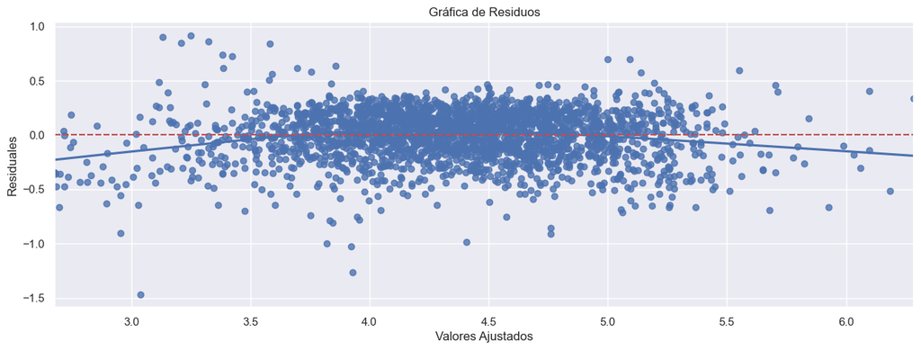

```python
# Gráfica de residuos
plt.figure(figsize=(15, 5))
sns.residplot(x=df_predicciones["Valores Ajustados"], y=df_predicciones["Residuales"],  lowess=True)
plt.title('Gráfica de Residuos')
plt.xlabel('Valores Ajustados')
plt.ylabel('Residuales')
plt.axhline(y=0, color='r', linestyle='--')
plt.show()
```

podemos observar que la grafica no sigue ningun patro, por lo tanto los suspuestos se cumplen.

### prueba de normallidad

esta prueba nos ayudara a comprobar si los valores estan distribuidos normalmente.

- haremos un histrograma de los residuos

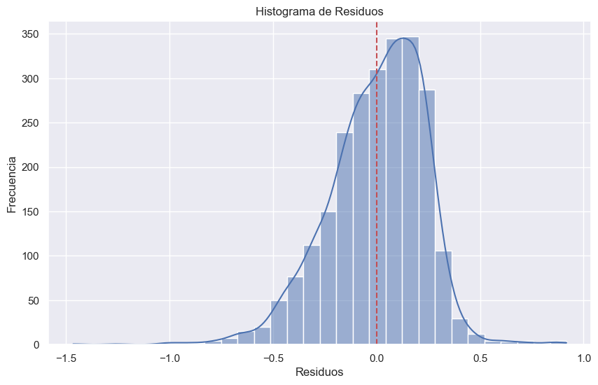

```python
plt.figure(figsize=(10, 6))
sns.histplot(df_predicciones["Residuales"], kde=True, bins=30)
plt.title('Histograma de Residuos')
plt.xlabel('Residuos')
plt.ylabel('Frecuencia')
plt.axvline(x=0, color='r', linestyle='--')
plt.show()
```

- podemos ver que el histograma de los residuos cumple con la forma de campana.

elaboraremos un grafico Q-Q

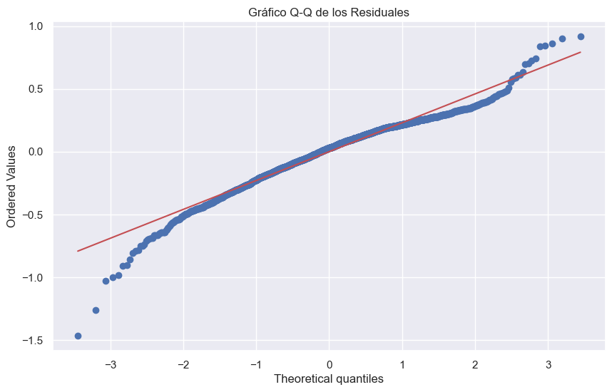

```python
import scipy.stats as stats
import matplotlib.pyplot as plt

# Gráfico Q-Q para los residuos
plt.figure(figsize=(10, 6))
stats.probplot(df_predicciones["Residuales"], plot=plt)
plt.title('Gráfico Q-Q de los Residuales')
plt.show()
```

podemos ver que los residuos siguen aproximadamente la diagonal, por lo que podemos ve rque se distribuyen normalmente, podemos tambien apreciar que existe un poco de desviacion en las colas.

- realizaremos la prueba de shapiro-wilk para comprobar los resultados.

```python
stats.shapiro(df_predicciones["Residuales"])
```

```
ShapiroResult(statistic=0.96908038854599, pvalue=2.1036324043233121e-22)
```

estrictamente nuestros residuos no son normales pero podemos decir que comun aproximacion, podemos aceptar esta distribucion cerca de ser normal.

#### prueba de homoscedasticidad

Verificar la homocedasticidad es esencial para garantizar la validez y confiabilidad de los resultados de un modelo de regresión lineal. Si se detecta heterocedasticidad, es posible que sea necesario corregir o transformar los datos o el modelo para abordarla.

```python
import statsmodels.stats.api as sms
from statsmodels.compat import lzip

name = ["F statistic", "p-value"]
test = sms.het_goldfeldquandt(df_predicciones["Residuales"], x_train3)
lzip(name, test)
```

```
[('F statistic', 1.044990694161013), ('p-value', 0.22343886791173048)]
```

podemos ver que aqui el p values es mayor a 0.05 por lo que el supuesto se cumple

### Comparacion de la prediccion con los datos actuales

al comprobar que los supuestos anteriores se han cumplido, ahora pasaremos a comprara las predicciones del modelo.

```python
# predicciones
pred = olsmod2.predict(x_test3)

df_pred_test = pd.DataFrame({"Actual": y_test, "Predecido": pred})
df_pred_test.sample(10, random_state=1)
```

|  | Actual | Predecido |
| --- | --- | --- |
| 1995 | 4.567 | 4.372 |
| 2341 | 3.696 | 3.961 |
| 1913 | 3.592 | 3.688 |
| 688 | 4.306 | 4.117 |
| 650 | 4.522 | 5.162 |
| 2291 | 4.259 | 4.397 |
| 40 | 4.998 | 5.449 |
| 1884 | 3.875 | 4.060 |
| 2538 | 4.207 | 4.059 |
| 45 | 5.380 | 5.305 |

podemos observar que el modelo nos arroga unos resultados bastante deseables, ya que los resultados de los valores actuales con los predichos son bastante parecidos.

## Modelo Final

revisaremos el rendimiento y el resumen del modelo final

```python
x_train_final = x_train3.copy()
x_test_final = x_test3.copy()
```

```python
olsmodel_final = sm.OLS(y_train, x_train_final).fit()
print(olsmodel_final.summary())
```

```
                              OLS Regression Results
=================================================================================
Dep. Variable:     normalized_used_price   R-squared:                       0.840
Model:                               OLS   Adj. R-squared:                  0.839
Method:                    Least Squares   F-statistic:                     1054.
Date:                   Fri, 18 Aug 2023   Prob (F-statistic):               0.00
Time:                           22:44:54   Log-Likelihood:                 88.196
No. Observations:                   2417   AIC:                            -150.4
Df Residuals:                       2404   BIC:                            -75.12
Df Model:                             12
Covariance Type:               nonrobust
========================================================================================
                           coef    std err          t      P>|t|      [0.025      0.975]
----------------------------------------------------------------------------------------
const                    1.3150      0.046     28.462      0.000       1.224       1.406
screen_size              0.0291      0.003      9.732      0.000       0.023       0.035
main_camera_mp           0.0209      0.001     15.150      0.000       0.018       0.024
selfie_camera_mp         0.0132      0.001     12.335      0.000       0.011       0.015
ram                      0.0217      0.004      4.911      0.000       0.013       0.030
battery              -2.114e-05   7.21e-06     -2.932      0.003   -3.53e-05      -7e-06
weight                   0.0008      0.000      6.585      0.000       0.001       0.001
normalized_new_price     0.4348      0.011     40.990      0.000       0.414       0.456
years_since_release     -0.0231      0.003     -6.742      0.000      -0.030      -0.016
brand_name_Infinix       0.2112      0.085      2.499      0.013       0.045       0.377
brand_name_Lenovo        0.0506      0.022      2.341      0.019       0.008       0.093
brand_name_Xiaomi        0.0952      0.026      3.709      0.000       0.045       0.146
4g_yes                   0.0437      0.015      2.928      0.003       0.014       0.073
==============================================================================
Omnibus:                      243.462   Durbin-Watson:                   1.909
Prob(Omnibus):                  0.000   Jarque-Bera (JB):              486.823
Skew:                          -0.647   Prob(JB):                    1.94e-106
Kurtosis:                       4.778   Cond. No.                     6.01e+04
==============================================================================

Notes:
[1] Standard Errors assume that the covariance matrix of the errors is correctly specified.
[2] The condition number is large, 6.01e+04. This might indicate that there are
strong multicollinearity or other numerical problems.
```

```python
# verificando el rendimiento del modelo de entrenamiento
print("Training Performance\n")
olsmodel_final_train_perf = model_performance_regression(
    olsmodel_final, x_train_final, y_train
)
olsmodel_final_train_perf
```

```
Training Performance
```

|  | RMSE | MAE | R-squared | Adj. R-squared | MAPE |
| --- | --- | --- | --- | --- | --- |
| 0 | 0.233 | 0.183 | 0.840 | 0.839 | 4.383 |

```python
# verificando el rendimiento del modelo de prueba
print("Test Performance\n")
olsmodel_final_test_perf = model_performance_regression(
    olsmodel_final, x_test_final, y_test
)
olsmodel_final_test_perf
```

```
Test Performance
```

|  | RMSE | MAE | R-squared | Adj. R-squared | MAPE |
| --- | --- | --- | --- | --- | --- |
| 0 | 0.237 | 0.183 | 0.844 | 0.842 | 4.471 |

podemos verificar lo que se mencionó antes

por lo tanto, se concluye que el modelo sastiface nuestras necesidades.

## Información práctica y recomendaciones

Se puede llegar a varias recomendaciones y conclusiones. pero primero se denotaran las siguientes observaciones

1. Relación General: El modelo explica un 84% (R-squared) de la variabilidad en el precio de teléfonos/tabletas usados basado en las variables incluidas. Esto es bastante significativo, mostrando que el modelo tiene un buen poder explicativo.
2. Variables Significativas: La mayoría de las variables en el modelo son significativas (p < 0.05), lo que indica que tienen un efecto significativo en la determinación del precio de venta de un dispositivo usado.
3. Características del Dispositivo:

Tamaño de pantalla: Por cada cm adicional en el tamaño de pantalla, el precio del dispositivo usado aumenta en promedio 0.0291 unidades (euros).

Cámaras: La resolución de la cámara principal y la cámara frontal influyen positivamente en el precio. Específicamente, por cada megapíxel adicional en la cámara principal, el precio aumenta 0.0209 unidades, mientras que para la cámara frontal, el aumento es de 0.0132 unidades.

RAM: Cada GB adicional de RAM aumenta el precio del dispositivo usado en 0.0217 unidades.

Batería: Sorprendentemente, hay una correlación negativa entre la capacidad de la batería y el precio. Sin embargo, este coeficiente es extremadamente pequeño, por lo que este efecto podría no ser muy significativo en la práctica.

Peso: Por cada gramo adicional en el peso del dispositivo, el precio aumenta en 0.0008 unidades.

Precio de Nuevo: El precio original de un dispositivo tiene una correlación muy fuerte con su precio de reventa. Por cada unidad adicional en el precio original, el precio del dispositivo usado aumenta en 0.4348 unidades.

Antigüedad: Por cada año adicional desde el lanzamiento del dispositivo, el precio disminuye en 0.0231 unidades. Esto es esperado ya que los dispositivos más antiguos tienden a depreciarse más.

1. Características de la Marca: Las marcas Infinix, Lenovo y Xiaomi tienen coeficientes positivos, lo que sugiere que, en promedio, los dispositivos de estas marcas tienen precios más altos en el mercado de segunda mano comparado con la marca base (que podría ser una marca no listada).
2. Conectividad 4G: Tener 4G aumenta el precio en 0.0437 unidades. Es interesante que no se mencione el 5G, ya que esto podría ser un factor significativo en años futuros.

Recomendaciones para ReCell:

- Estrategia de Precios: Aprovechar las variables que más impactan en el precio de reventa (como el tamaño de pantalla, resolución de las cámaras y RAM) para establecer una estrategia de precios dinámica.
- Inventario: Considerando que las marcas Infinix, Lenovo y Xiaomi tienden a tener un mayor precio de reventa, podría ser beneficioso centrarse en la adquisición de estos dispositivos.
- Publicidad: Promocionar la disponibilidad de 4G en dispositivos puede atraer a más compradores, ya que parece ser un factor deseado.
- Estudio Futuro: Sería relevante incluir el 5G como una variable en futuros análisis, dado el crecimiento de esta tecnología.

-